# Sesion 5

jairo urdaneta y Adrian Villegas

2026-04-23

# Review de la sesion pasada

La sesion pasada escogimos dos de nuestros modelos, los analizamos y descubrimos que:

**LM-Nota final**

✕ Asuncion de linealidad

✕ Asuncion de homocedasticidad

✕ Asuncion de normalidad

✓ Asuncion de ouliers influyentes

✓ Asuncion de multicorrelacion

✓ Independencia de observaciones

**LM-Horas de smartphone**

✓ Asuncion de linealidad

✕ Asuncion de homocedasticidad

✓ Asuncion de normalidad

✓ Asuncion de ouliers influyentes

✓ Asuncion de multicorrelacion

✓ Independencia de observaciones

Sabiendo que asunciones no se cumplen en este informe vamos a tratar de corregirlas usando logaritmos y en caso de no tener buenos resultados buscaremos otras opciones.

# Correcion de las asunciones

## Modelo de prediccion-Nota final

**Descripcion del modelo**

Nota_fina_examen ~ horas_de_estudio + horas_sueño + nivel_motivacion + porcentaje_asistencia_clase

Es un modelo que utiliza 4 variables predictoras: Horas de estudio, Horas de sueño, Nivel de motivación y Porcentaje de asistencia a clases

```r
modelo_multivariable_nota <- lm(final_exam_score ~ study_hours_per_day + sleep_hours + motivation_level + class_attendance_percent, data = student_digital_life)
```

Todas nuestras variables son significativas para nuestro modelo. Aparentemente nuestro modelo paraceria estar correcto, pero el analisis de las asunciones mostro que no cumple 3 de estas: linealidad, homocedasticidad y normalidad. Acontinuacion vamos a corregirlas.

**Aplicacion de Logaritmos**

Primero comprobamos cuales de nuestras variables predictoras necesitan correccion.

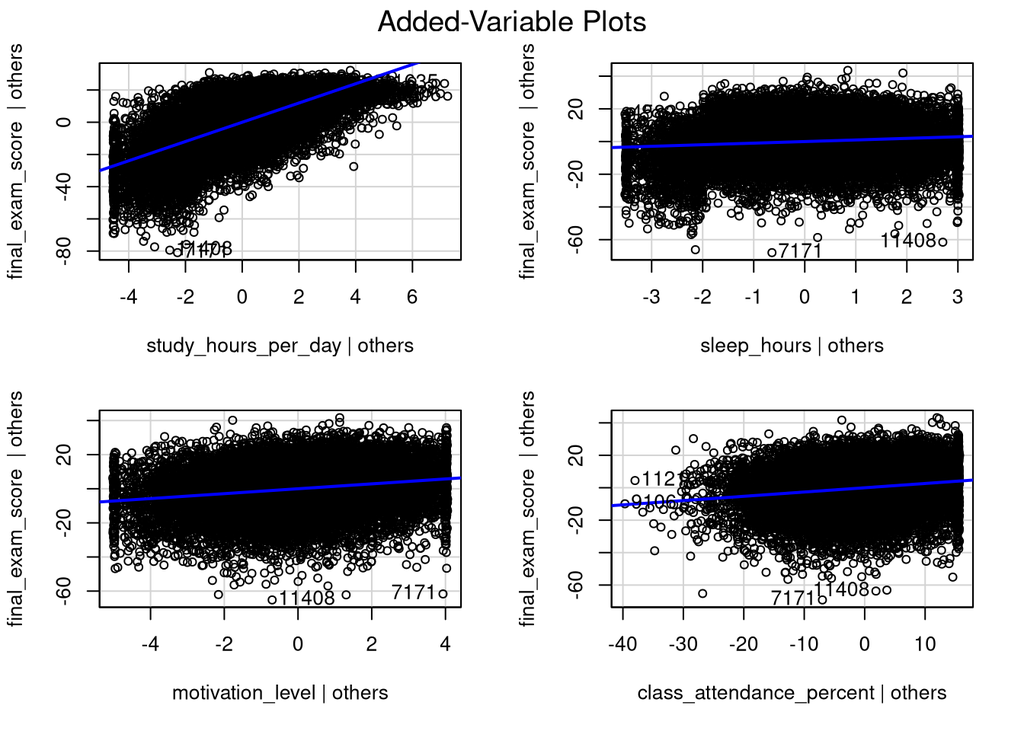

```r
avPlots(modelo_multivariable_nota)
```

```r
modelo_multivariable_nota_corregido <- lm(log(final_exam_score) ~ log(study_hours_per_day+1) + sleep_hours + log(motivation_level) + log(class_attendance_percent), data = student_digital_life)
```

**Linealidad y Homocedasticidad**

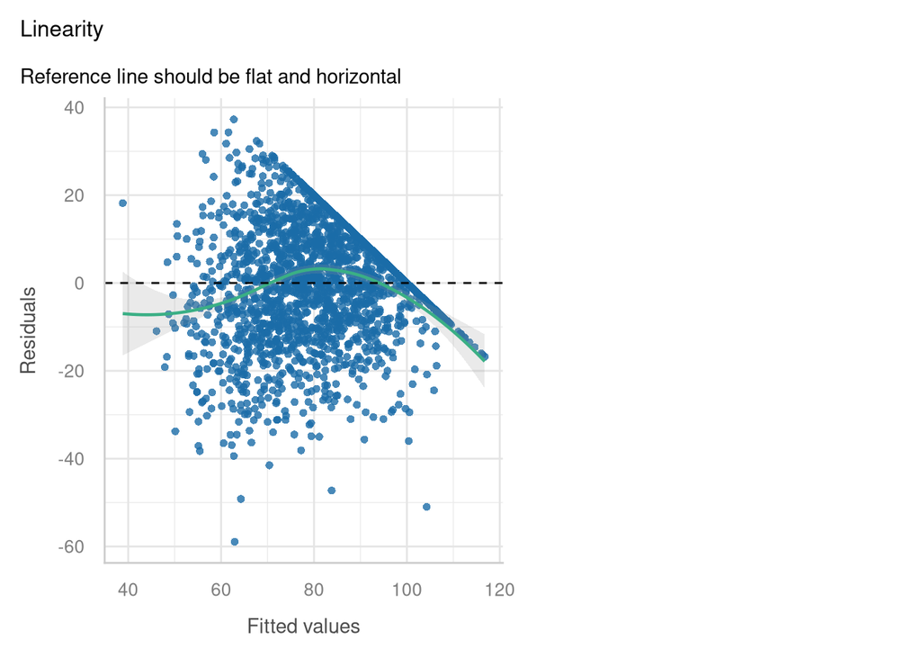

```r
check_model(modelo_multivariable_nota, check="linearity")
```

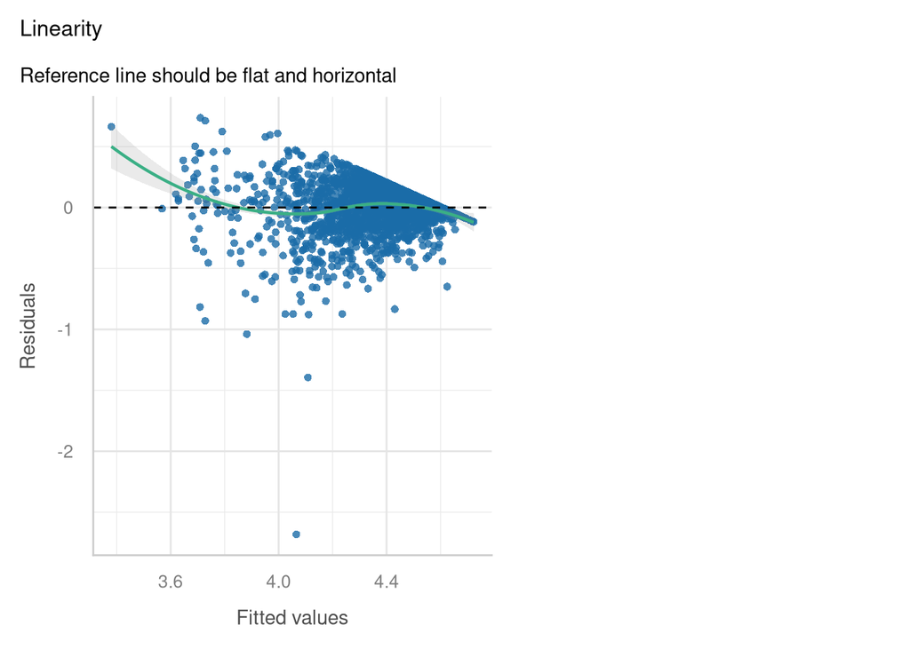

```r
check_model(modelo_multivariable_nota_corregido, check="linearity")
```

Vemos que el emplear los logaritmos, la recta se suaviza esta mas centrada en 0, no es perfecto del todo pero es una gran correccion que antes de aplicar los logaritmos. Podriamos decir que hemos mejorado la linealidad pero aun seguimos presentando heterocedasticidad en los residuos.

**Normalidad**

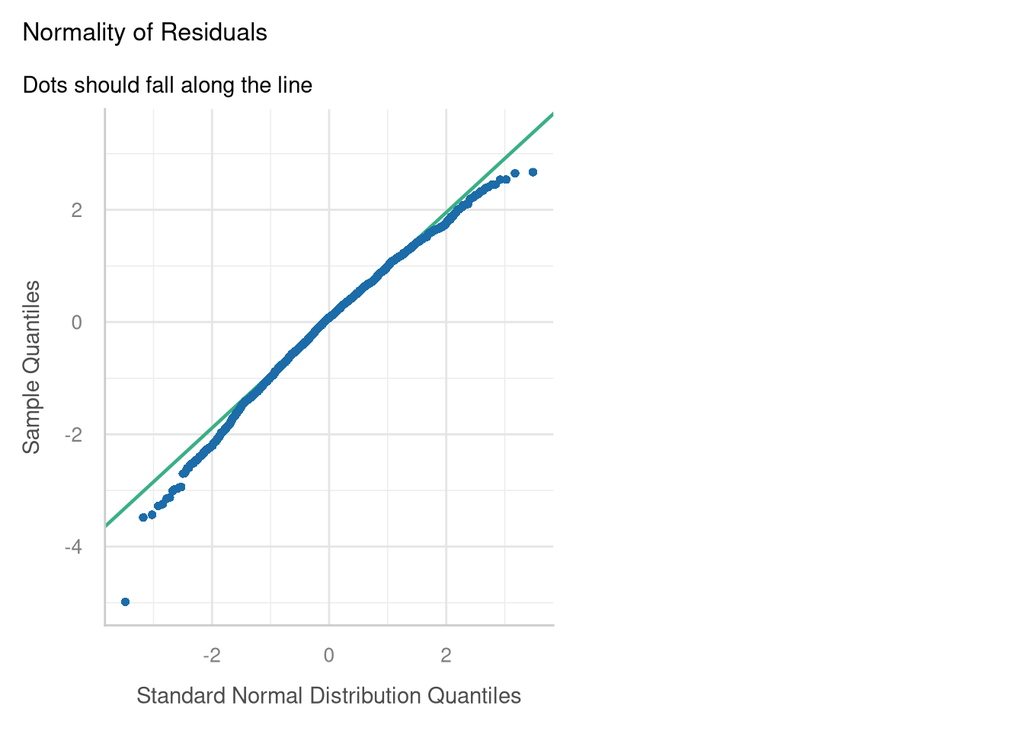

```r
check_model(modelo_multivariable_nota, check="qq", detrend=FALSE)
```

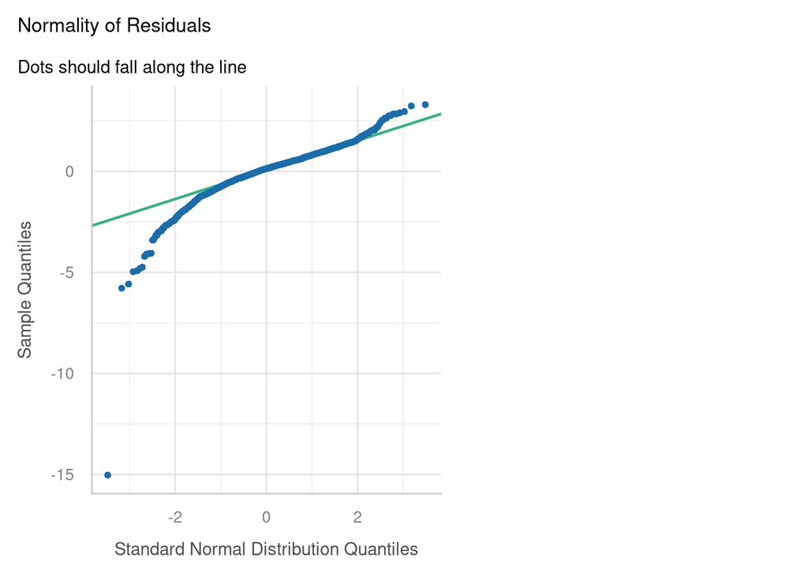

```r
check_model(modelo_multivariable_nota_corregido, check="qq", detrend=FALSE)
```

La aplicacion de logaritmos solo nos ha ayudado a arreglar la linealidad, la homocedasticidad no parece haberse arreglado y hemos empeorado la normalidad comparado con el modelo anterior. El uso de logaritmos no es suficiente para nuestro modelo, necesitariamos usar modelos mas avanzados GLM.

## Modelo de prediccion-Horas smartphone

**Descripcion del modelo**

Horas_uso_smartphone ~ horas_de_estudio + horas_de_streaming + horas_ejercicio + calificacion_examen_final

Es un modelo que utiliza 4 variables predictoras: Horas de estudio, Horas de streaming, Horas de ejercicio y La nota que obtuvieron en el examen.

```r
modelo_multivariable_smart <- lm( smartphone_usage_hours ~ study_hours_per_day + streaming_hours + exercise_hours + final_exam_score , data = student_digital_life)
```

Todas nuestras variables son significativas para nuestro modelo. Aparentemente nuestro modelo paraceria estar correcto, pero el analisis de las asunciones mostro que no cumple 1 la homocedasticidad. A continuacion vamos a corregirla usando dos metodos y ver cual es mejor.

**Correccion Homocedasticidad usando logaritmos**

Primero comprobamos cuales de nuestras variables predictoras necesitan correccion.

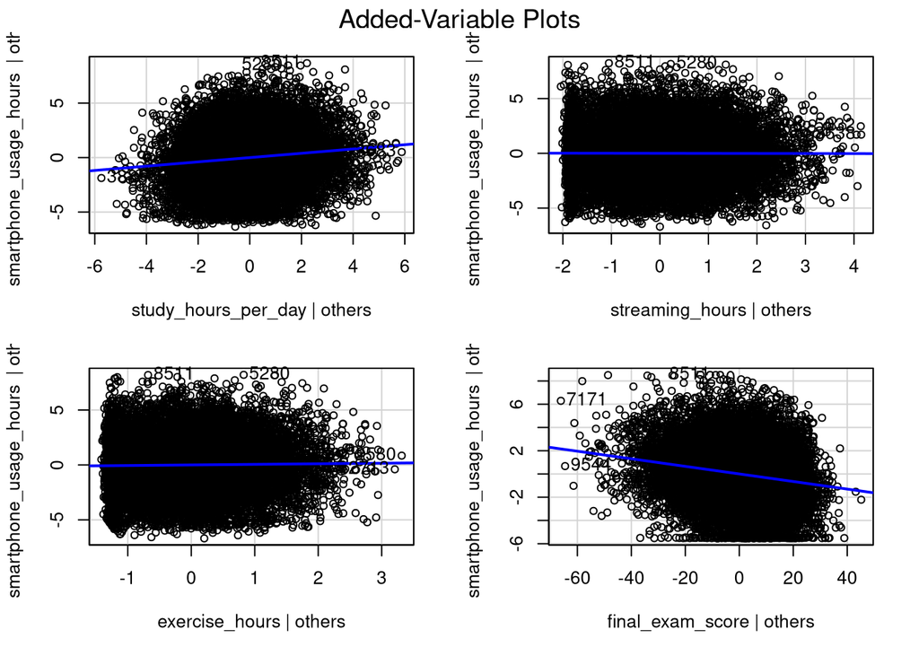

```r
avPlots(modelo_multivariable_smart)
```

Aplicamos algoritmos a las variables que tienen un ascenso o descenso en su recta.

```r
modelo_multivariable_smart_corregido <- lm( log(smartphone_usage_hours+1) ~ log(study_hours_per_day+1) + streaming_hours + exercise_hours + log(final_exam_score) , data = student_digital_life)
```

Verificamos los graficos de Antes y Despues de las correcciones

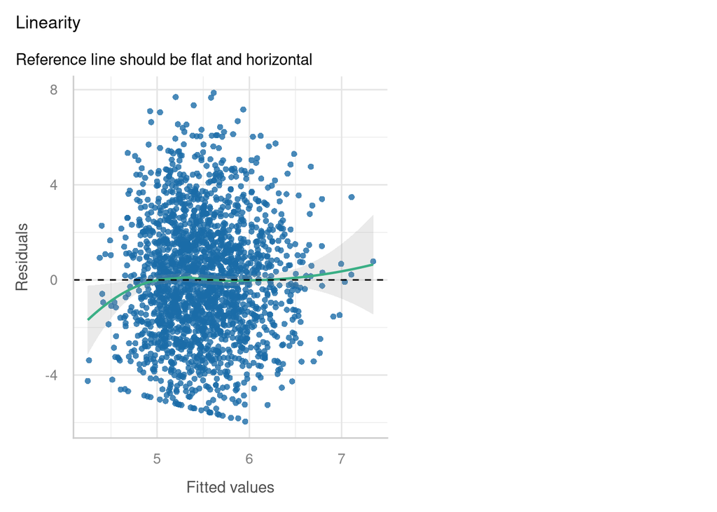

```r
check_model(modelo_multivariable_smart, check="linearity")
```

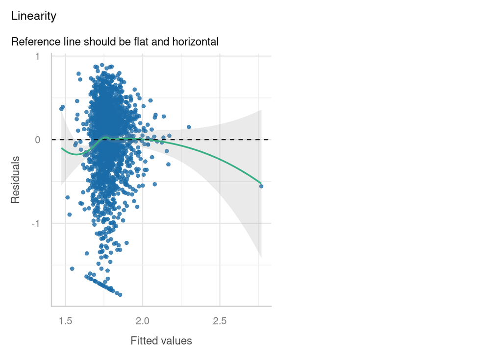

```r
check_model(modelo_multivariable_smart_corregido, check="linearity")
```

Vemos que el emplear los logaritmos, la recta se curva y ahora no solo seguimos sin cumplir la homocedasticidad sino que hemos creado otra asuncion. Intentaremos corregir la asuncion usando otro metodo.

**Correccion Homocedasticidad usando VarExp**

```r
modelo_multivariable_smart_corregido <- gls(smartphone_usage_hours ~ study_hours_per_day + streaming_hours + exercise_hours + final_exam_score , data = student_digital_life, weights = varExp(form = ~ final_exam_score))
```

Graficos de Antes y Despues

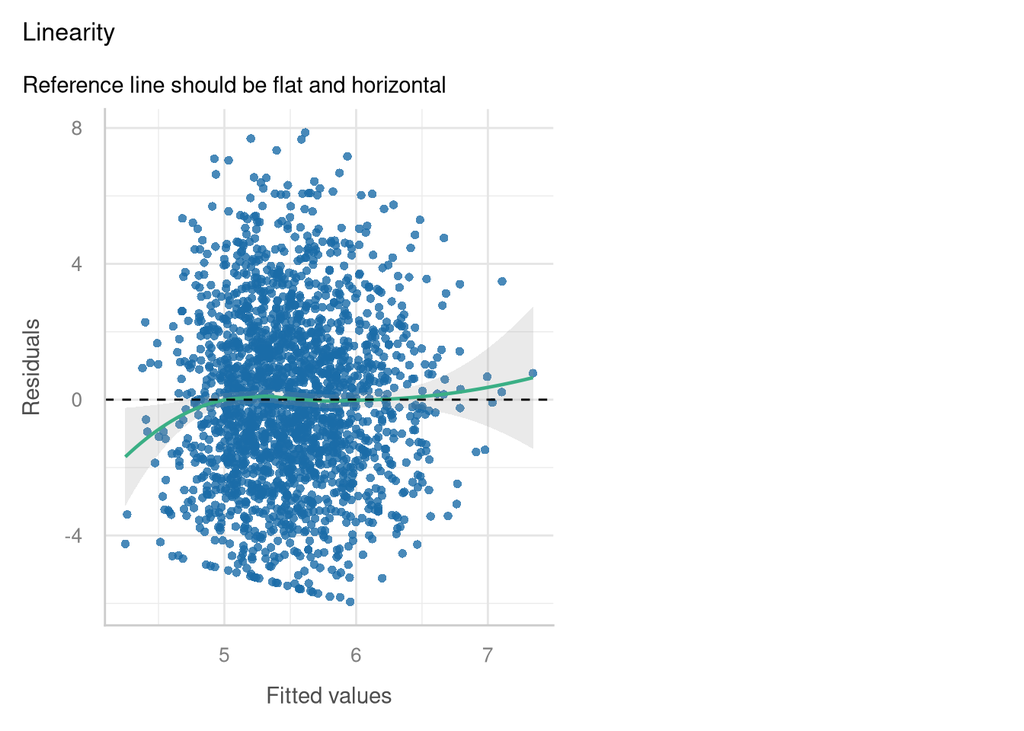

```r
check_model(modelo_multivariable_smart, check="linearity")
```

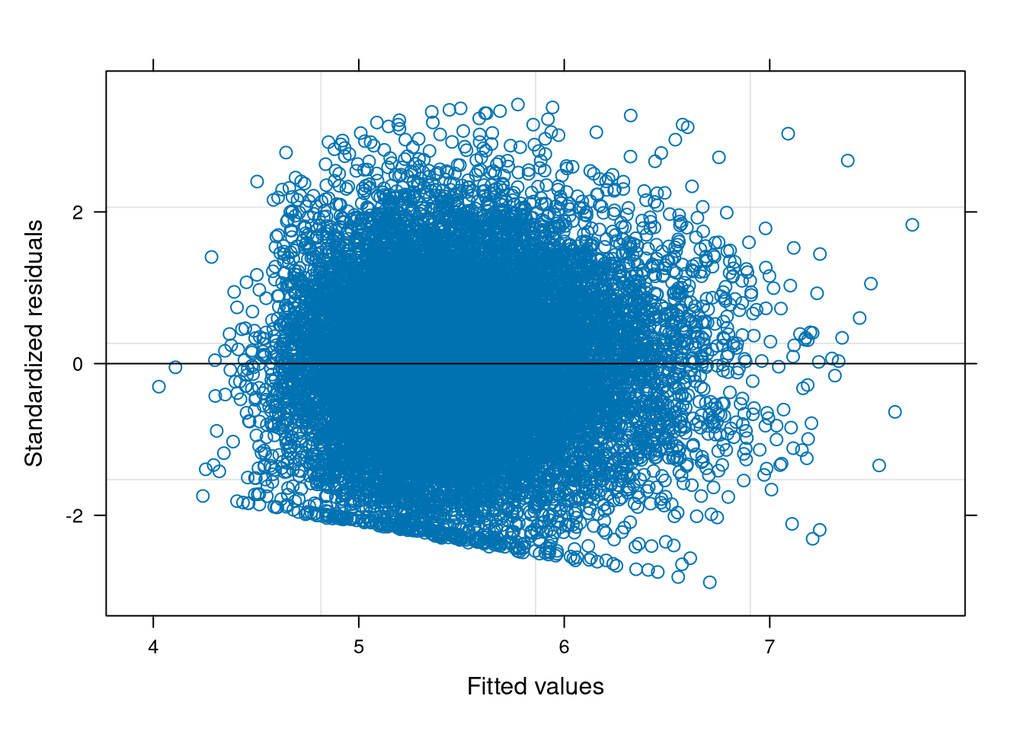

```r
plot(modelo_multivariable_smart_corregido, abline = 0)
```

Vemos una distribuccion de los residuos mucho mejor, mayor uniformidad pero no del todo perfecto. Aun asi daremos como bueno este modelo y tomaremos como corregida la homocedasticidad.

# Verificacion Asunciones

Volvemos a verificar los modelos corregidos a ver si no hemos creado alguna otra asuncion.

**Linealidad y homocedasticidad**

- Modelo prediccion nota

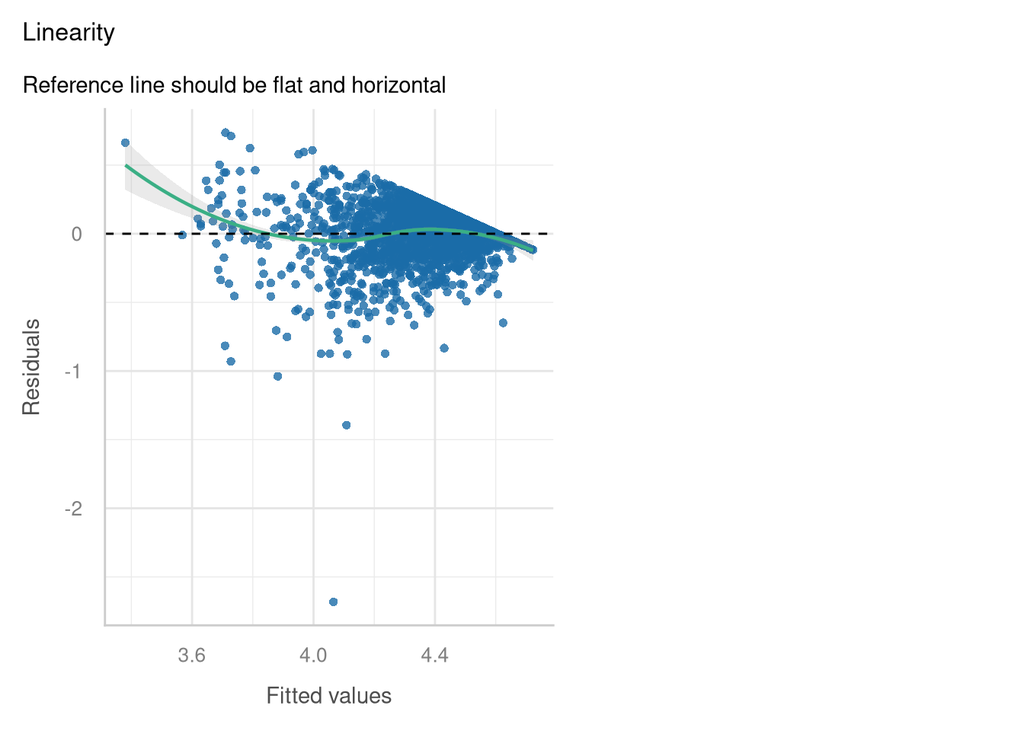

```r
check_model(modelo_multivariable_nota_corregido, check="linearity")
```

Suavizamos la recta ahora esta mas a pegada al 0 pero no es una corregion al completo, aparte seguimos presentando heterocedasticidad.

- Modelo prediccion horas smart

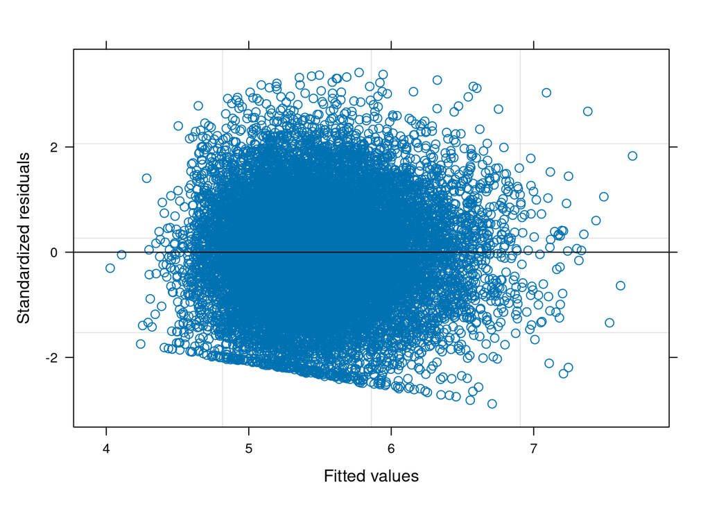

```r
plot(modelo_multivariable_smart_corregido, abline=0)
```

Nuestro modelo anterior ya cumplia la linealidad y ahora parece que hemos corregido un poco la heterocedasticidad de la que sufriamos.

**Normalidad**

- Modelo prediccion nota

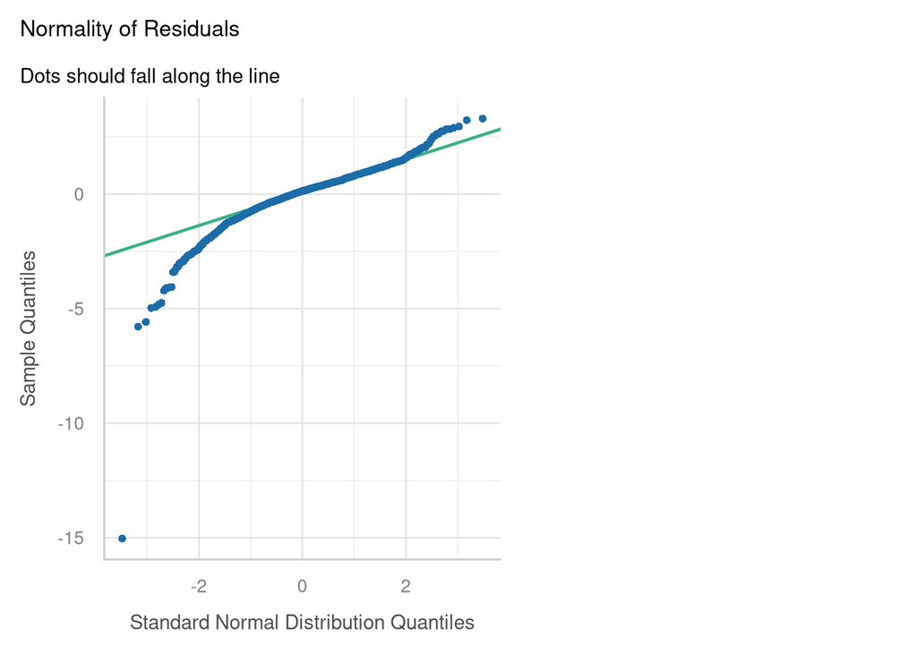

```r
check_model(modelo_multivariable_nota_corregido, check="qq", detrend=FALSE)
```

Anteriormente seguiamos sin cumplir la normalidad pero con la aplicacion de algoritmos solo hemos empeorado

- Modelo prediccion horas smart

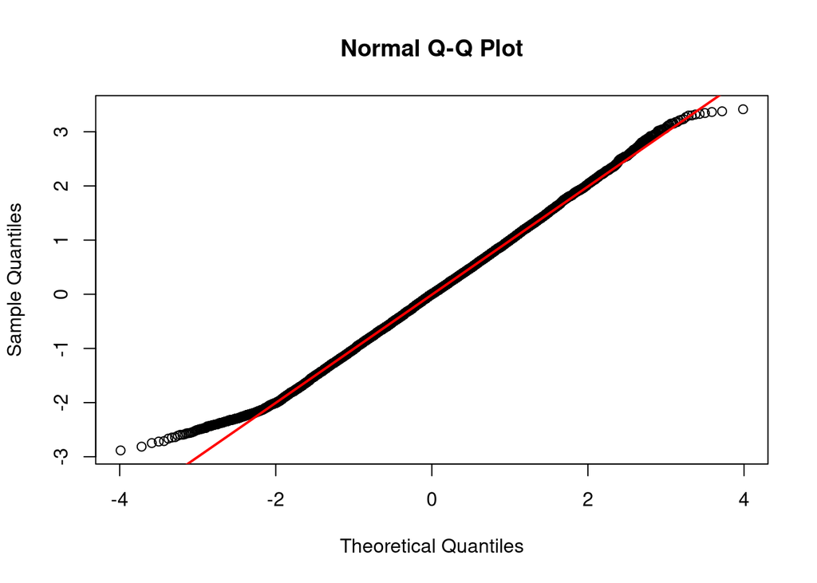

```r
res <- resid(modelo_multivariable_smart_corregido, type = "p")
qqnorm(res)
qqline(res, col = "red", lwd = 2)
```

Seguimos manteniendo la normalidad inclusive parece haber mejorado un poco a comparacion del modelo anterior.

**Outliers influyentes**

- Modelo prediccion nota

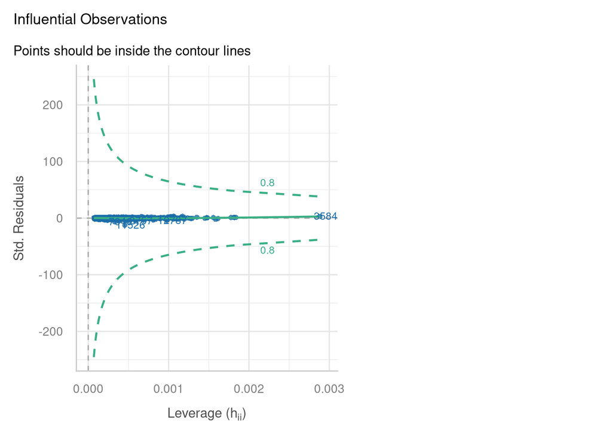

```r
check_model(modelo_multivariable_nota_corregido, check="outliers")
```

Seguimos sin outliers influyentes para este modelo.

- Modelo prediccion horas smart

```r
check_outliers(modelo_multivariable_smart_corregido)
```

```
## Converting missing values (`NA`) into regular values currently not
##   possible for variables of class `NULL`.
```

```
## OK: No outliers detected.
## - Based on the following method and threshold:  ().
## - For variable: (Whole model)
```

Seguimos sin outliers influyentes para este modelo.

**Multicorrelacion**

- Modelo prediccion nota

```r
vif(modelo_multivariable_nota_corregido)
```

```
##  log(study_hours_per_day + 1)                   sleep_hours
##                      1.000070                      1.000056
##         log(motivation_level) log(class_attendance_percent)
##                      1.000144                      1.000132
```

Seguimos cumpliendo la ausencia de multicolinealidad.

- Modelo prediccion horas smart

```r
vif(modelo_multivariable_smart_corregido)
```

```
## study_hours_per_day     streaming_hours      exercise_hours    final_exam_score
##            1.730034            1.002106            1.006514            1.735900
```

Seguimos cumpliendo la ausencia de multicolinealidad.

# Evaluacion de los modelos

Evaluacion de los ajustes relativos y absolutos de nuestros modelos.

- Modelo Prediccion nota

Vamos a comparar las metricas del modelo antes y despues de sus correcciones

```r
compare_performance(modelo_multivariable_nota, modelo_multivariable_nota_corregido)
```

```
## # Comparison of Model Performance Indices
##
## Name                                | Model |   AIC (weights) |  AICc (weights)
## -------------------------------------------------------------------------------
## modelo_multivariable_nota           |    lm | 1.2e+05 (>.999) | 1.2e+05 (>.999)
## modelo_multivariable_nota_corregido |    lm | 1.3e+05 (<.001) | 1.3e+05 (<.001)
##
## Name                                |   BIC (weights) |    R2 | R2 (adj.)
## -------------------------------------------------------------------------
## modelo_multivariable_nota           | 1.2e+05 (>.999) | 0.462 |     0.462
## modelo_multivariable_nota_corregido | 1.3e+05 (<.001) | 0.437 |     0.437
##
## Name                                |   RMSE |  Sigma
## -----------------------------------------------------
## modelo_multivariable_nota           | 13.518 | 13.520
## modelo_multivariable_nota_corregido |  0.216 |  0.216
```

El RSME no se puede comparar de la misma forma por la aplicacion del logaritmo. Transformamos a las unidades originales para compararlos

```r
pred_orig <- predict(modelo_multivariable_nota)
rmse_orig <- sqrt(mean((student_digital_life$final_exam_score - pred_orig)^2))

# Volver a escala original modelo con log
pred_corr_log <- predict(modelo_multivariable_nota_corregido)
pred_corr_original_scale <- exp(pred_corr_log)  # Back-transformation

# Calcular RMSE en escala original
rmse_corr <- sqrt(mean((student_digital_life$final_exam_score - pred_corr_original_scale)^2))

# Comparar
data.frame(
  Modelo = c("Original", "Corregido (back-transformed)"),
  RMSE_escala_original = c(rmse_orig, rmse_corr)
)
```

```
##                         Modelo RMSE_escala_original
## 1                     Original             13.51812
## 2 Corregido (back-transformed)             13.47995
```

La comparacion de los ajustes de ambos modelos:

**AIC**: El modelo antiguo tiene mejor AIC

**RMSE**: Modelo actual tiene menos RMSE

**R^2 ajustado** Un valor R^2 ajustado por parte del primer modelo

Concluimos con la comparacion de los dos modelos que el primer modelo pese a no cumplir las asunciones de linealidad, homocedasticidad y normalidad tiene mejores resultados que el modelo que supuestamente habiamos corregido. De todas formas habiamos concluido que este modelo necesitaria usar otro tipo de modelo lineal posiblemente un GLM.

- Modelo Prediccion smartphone

Vamos a comparar las metricas del modelo antes y despues de sus correcciones

```r
compare_performance(modelo_multivariable_smart, modelo_multivariable_smart_corregido)
```

```
## # Comparison of Model Performance Indices
##
## Name                                 | Model |   AIC (weights)
## --------------------------------------------------------------
## modelo_multivariable_smart           |    lm | 68769.2 (0.120)
## modelo_multivariable_smart_corregido |   gls | 68765.2 (0.880)
##
## Name                                 |   BIC (weights) |    R2 |  RMSE | Sigma
## ------------------------------------------------------------------------------
## modelo_multivariable_smart           | 68814.9 (0.860) | 0.035 | 2.394 | 2.394
## modelo_multivariable_smart_corregido | 68818.5 (0.140) | 0.035 | 2.394 | 2.250
##
## Name                                 |  AICc (weights) | R2 (adj.)
## ------------------------------------------------------------------
## modelo_multivariable_smart           | 68769.2 (>.999) |     0.035
## modelo_multivariable_smart_corregido |         (>.999) |
```

La comparacion de los ajustes de ambos modelos:

**AIC**: Modelo actual tiene mejor AIC debido a la mejora de la heterocedasticidad

**RMSE**: Ambos modelos igual

**R^2 ajustado**: Ambos modelos tienen un R^2 ajustado de 3.5% muy bajo por lo que no explican bien la variabilidad.

Conclusiones en las comparaciones. Nuestro modelo actual tiene mejor rendimiento que el anterior pero nuestro mayor problema es que tenemos un R^2 muy bajo, por lo que en futuras practicas mejoraremos agregando mas variables para mejorar el R^2.